# Global Inequality in Child Wellbeing

A UNICEF Data Analysis

Author

UNICEF Data Analyst

Published

April 24, 2025

# Executive Summary

This report examines two critical aspects of child wellbeing around the world:

1. **Paternity leave benefits** - Policies that allow fathers to take time off work when a child is born
2. **Healthcare waste management** - The availability of proper waste management services in healthcare facilities

Using data from UNICEF and related sources, we analyze regional patterns, compare indicators, and explore how these factors vary across different parts of the world. Our findings highlight significant disparities in policy implementation and healthcare infrastructure that directly impact children’s lives.

# Introduction

Creating environments where children can thrive requires **supportive policies** and **adequate healthcare infrastructure**. This analysis focuses on:

- The availability of **paternity leave benefits**, which affect family dynamics and early childhood care
- The status of **healthcare waste management**, which impacts the safety and quality of health services

Together, these indicators provide insight into how countries prioritize children’s wellbeing through both family policy and health system infrastructure.

# Data and Methodology

## Data Sources

This analysis uses three primary datasets from UNICEF:

- **Indicator 1**: Paternity leave benefits (binary Yes/No data)
- **Indicator 2**: Proportion of health care facilities with limited health care waste management services
- **Metadata**: Country-level socioeconomic indicators

```python
import pandas as pd
import numpy as np
import matplotlib.pyplot as plt
import seaborn as sns
from matplotlib.colors import LinearSegmentedColormap

# Set visual style
plt.style.use('seaborn-v0_8-whitegrid')
sns.set_palette("colorblind")

# Custom colors
primary_color = "#0066cc"
secondary_color = "#ff9933"
highlight_color = "#cc0000"

# Load datasets
print("Loading data files...")
indicator1 = pd.read_csv("unicef_indicator_1.csv")
indicator2 = pd.read_csv("unicef_indicator_2.csv")
metadata = pd.read_csv("unicef_metadata.csv")

# Show basic info
print(f"Indicator 1: {indicator1['indicator'].iloc[0]}")
print(f"Indicator 2: {indicator2['indicator'].iloc[0]}")
```

[output not shown]

## Dataset Structure

Our datasets contain information about:

- **Country identifiers**: Names, codes, and geographic information
- **Indicators**: Paternity leave (Yes/No) and healthcare waste management metrics
- **Time periods**: Years for which data is available
- **Sex disaggregation**: Total, male, female (where applicable)
- **Socioeconomic context**: GDP, population, life expectancy, etc.

# Paternity Leave Benefits Worldwide

## Global Implementation Status

Paternity leave is an important policy that allows fathers to participate in early childcare, supporting child development and gender equality in parenting.

```
Latest year available: 2024
```

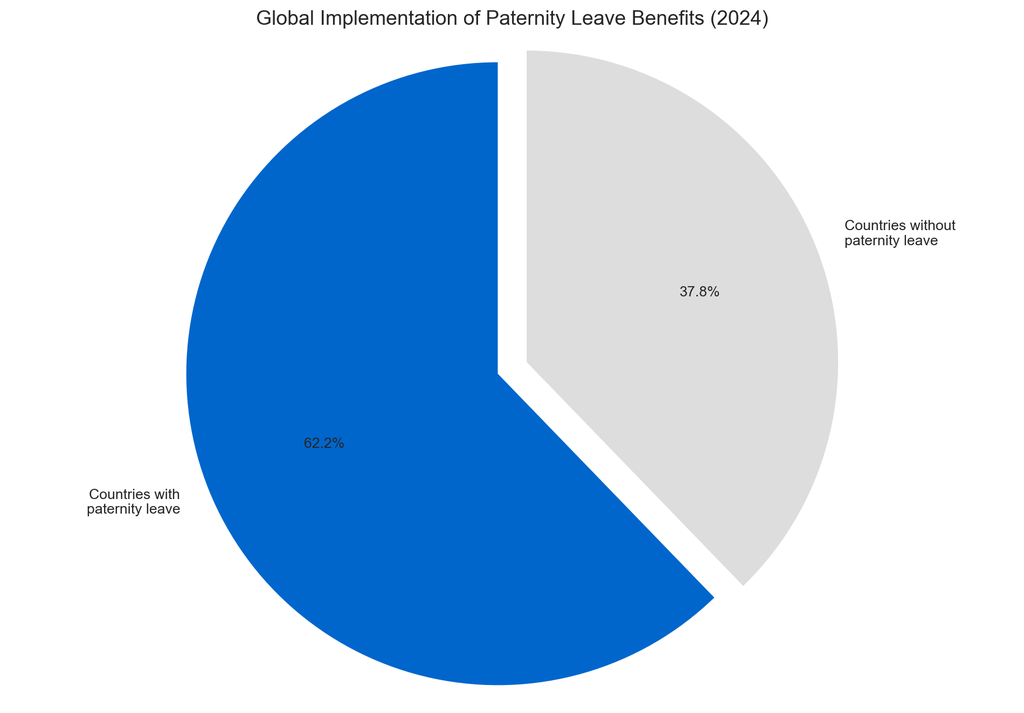

Implementation of Paternity Leave Benefits by Country

```
Countries with paternity leave: 117 (62.2%)
Countries without paternity leave: 71 (37.8%)
```

```python
# Get latest year for paternity leave data
latest_year = indicator1['time_period'].max()
print(f"Latest year available: {latest_year}")

# Filter for latest year and total
latest_ind1 = indicator1[(indicator1['time_period'] == latest_year) &
                        (indicator1['sex'] == 'Total')]

# Count yes/no responses
response_counts = latest_ind1['obs_value'].value_counts()
total_countries = len(latest_ind1)

# Calculate percentages
yes_count = sum(latest_ind1['obs_value'] == 'Yes')
yes_percentage = yes_count / total_countries * 100 if total_countries > 0 else 0
no_percentage = 100 - yes_percentage

# Create a pie chart
plt.figure(figsize=(10, 7))
plt.pie([yes_percentage, no_percentage],
        labels=['Countries with\npaternity leave', 'Countries without\npaternity leave'],
        autopct='%1.1f%%',
        colors=[primary_color, '#dddddd'],
        explode=(0.1, 0),
        startangle=90,
        shadow=False)
plt.title(f'Global Implementation of Paternity Leave Benefits ({latest_year})', fontsize=14)
plt.axis('equal')
plt.tight_layout()
plt.show()

print(f"Countries with paternity leave: {yes_count} ({yes_percentage:.1f}%)")
print(f"Countries without paternity leave: {total_countries - yes_count} ({no_percentage:.1f}%)")
```

## Regional Analysis of Paternity Leave

Paternity leave implementation varies significantly by region, reflecting different cultural norms and policy priorities.

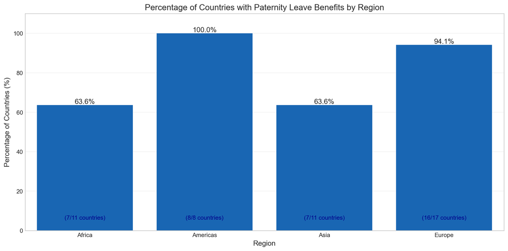

Regional Distribution of Paternity Leave Benefits

```python
# Define regions for analysis
regions = {
    'Africa': ['Nigeria', 'South Africa', 'Egypt', 'Kenya', 'Ethiopia', 'Ghana',
               'Morocco', 'Tanzania', 'Algeria', 'Tunisia', 'Uganda', 'Zambia'],
    'Americas': ['United States', 'Canada', 'Brazil', 'Mexico', 'Argentina',
                'Colombia', 'Chile', 'Peru', 'Venezuela'],
    'Asia': ['China', 'India', 'Japan', 'Indonesia', 'Pakistan', 'Bangladesh',
             'Philippines', 'Vietnam', 'Thailand', 'Malaysia', 'Singapore'],
    'Europe': ['United Kingdom', 'France', 'Germany', 'Italy', 'Spain', 'Russia',
              'Turkey', 'Poland', 'Ukraine', 'Romania', 'Netherlands', 'Belgium',
              'Sweden', 'Switzerland', 'Austria', 'Norway', 'Denmark', 'Finland']
}

# Analyze paternity leave by region
region_stats = []

for region, countries in regions.items():
    # Get countries in this region
    region_data = latest_ind1[latest_ind1['country'].isin(countries)]

    if len(region_data) > 0:
        yes_count = sum(region_data['obs_value'] == 'Yes')
        total = len(region_data)
        percentage = (yes_count / total) * 100

        region_stats.append({
            'Region': region,
            'Countries_With_Data': total,
            'Countries_With_PaternityLeave': yes_count,
            'Percentage': percentage
        })

# Convert to DataFrame
region_df = pd.DataFrame(region_stats)

# Create the bar chart
plt.figure(figsize=(12, 6))
ax = sns.barplot(x='Region', y='Percentage', data=region_df, color=primary_color)

# Add percentage labels on bars
for i, p in enumerate(ax.patches):
    ax.annotate(f"{p.get_height():.1f}%",
                (p.get_x() + p.get_width() / 2., p.get_height()),
                ha = 'center', va = 'bottom',
                fontsize=12)

# Add text showing countries with data
for i, row in region_df.iterrows():
    ax.annotate(f"({row['Countries_With_PaternityLeave']}/{row['Countries_With_Data']} countries)",
                (i, 5), ha='center', va='bottom', color='darkblue',
                fontsize=10)

plt.title('Percentage of Countries with Paternity Leave Benefits by Region', fontsize=14)
plt.xlabel('Region', fontsize=12)
plt.ylabel('Percentage of Countries (%)', fontsize=12)
plt.ylim(0, 110)  # Add space for annotations
plt.grid(axis='y', alpha=0.3)
plt.tight_layout()
plt.show()
```

## Paternity Leave and Economic Development

The availability of paternity leave often correlates with a country’s economic development level.

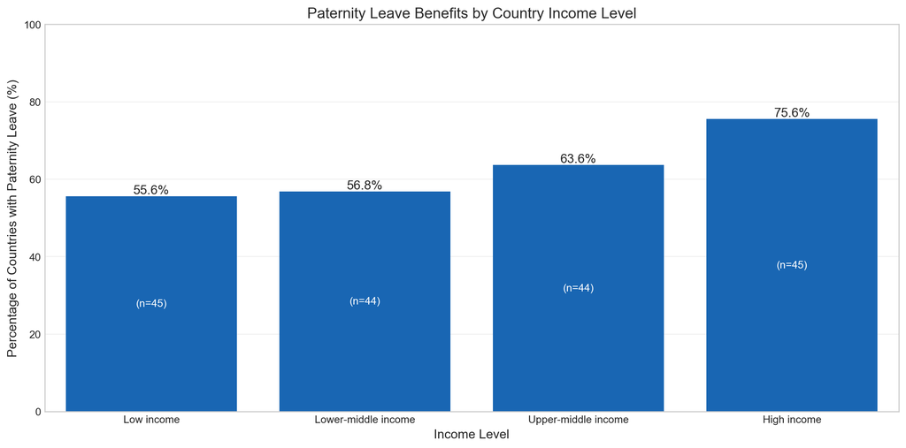

Paternity Leave Implementation by GDP Level

```python
# Get economic data from latest available year
latest_meta_year = metadata['year'].max()
latest_meta = metadata[metadata['year'] == latest_meta_year]

# Check if GDP column exists and prepare data
gdp_column = 'GDP per capita (constant 2015 US$)'

if gdp_column in latest_meta.columns:
    # Merge paternity leave with GDP data
    paternity_gdp = latest_ind1.merge(
        latest_meta[['country', gdp_column]],
        on='country',
        how='inner'
    )

    # Remove rows with missing GDP values
    paternity_gdp = paternity_gdp.dropna(subset=[gdp_column])

    if len(paternity_gdp) > 5:  # Ensure we have enough data
        # Group countries by GDP quartile
        paternity_gdp['GDP_quartile'] = pd.qcut(
            paternity_gdp[gdp_column],
            4,
            labels=['Low income', 'Lower-middle income', 'Upper-middle income', 'High income']
        )

        # Calculate percentage of countries with paternity leave by GDP quartile
        gdp_stats = paternity_gdp.groupby('GDP_quartile')['obs_value'].apply(
            lambda x: (x == 'Yes').mean() * 100
        ).reset_index()
        gdp_stats.columns = ['GDP_quartile', 'Percentage']

        # Add count information
        counts = paternity_gdp.groupby('GDP_quartile')['obs_value'].count().reset_index()
        counts.columns = ['GDP_quartile', 'Count']
        gdp_stats = gdp_stats.merge(counts, on='GDP_quartile')

        # Create bar chart
        plt.figure(figsize=(12, 6))
        ax = sns.barplot(x='GDP_quartile', y='Percentage', data=gdp_stats, color=primary_color)

        # Add percentage labels
        for i, p in enumerate(ax.patches):
            ax.annotate(f"{p.get_height():.1f}%",
                       (p.get_x() + p.get_width() / 2., p.get_height()),
                       ha = 'center', va = 'bottom',
                       fontsize=12)

            # Add count information
            count = gdp_stats.iloc[i]['Count']
            ax.annotate(f"(n={count})",
                       (p.get_x() + p.get_width() / 2., p.get_height()/2),
                       ha = 'center', va = 'center',
                       fontsize=10, color='white')

        plt.title('Paternity Leave Benefits by Country Income Level', fontsize=14)
        plt.xlabel('Income Level', fontsize=12)
        plt.ylabel('Percentage of Countries with Paternity Leave (%)', fontsize=12)
        plt.ylim(0, 100)
        plt.grid(axis='y', alpha=0.3)
        plt.tight_layout()
        plt.show()
    else:
        print("Insufficient data for GDP analysis")
else:
    print(f"GDP column '{gdp_column}' not found in metadata")
```

# Healthcare Waste Management

## Current Status

Proper waste management in healthcare facilities is crucial for preventing infection and ensuring safe environments for children seeking medical care.

```
Latest year for healthcare data: 2023
```

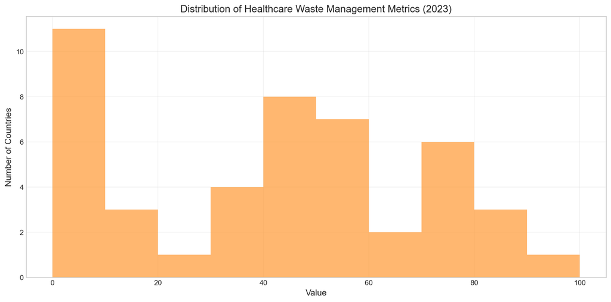

Status of Healthcare Waste Management Services

```python
# Get latest year for healthcare waste management data
latest_year2 = indicator2['time_period'].max()
print(f"Latest year for healthcare data: {latest_year2}")

# Filter for latest year and total
latest_ind2 = indicator2[(indicator2['time_period'] == latest_year2) &
                        (indicator2['sex'] == 'Total')]

# For waste management, get distribution of values
waste_values = latest_ind2['obs_value'].value_counts().reset_index()
waste_values.columns = ['Value', 'Count']

# Calculate percentages
waste_values['Percentage'] = waste_values['Count'] / waste_values['Count'].sum() * 100

# Check if it's numeric or categorical
try:
    # Try to convert to numeric
    latest_ind2['obs_value_num'] = pd.to_numeric(latest_ind2['obs_value'], errors='coerce')
    is_numeric = not latest_ind2['obs_value_num'].isna().all()

    if is_numeric:
        # For numeric data, create a histogram
        plt.figure(figsize=(12, 6))

        # Plot histogram
        plt.hist(latest_ind2['obs_value_num'].dropna(), bins=10, color=secondary_color, alpha=0.7)

        plt.title(f'Distribution of Healthcare Waste Management Metrics ({latest_year2})', fontsize=14)
        plt.xlabel('Value', fontsize=12)
        plt.ylabel('Number of Countries', fontsize=12)
        plt.grid(alpha=0.3)
        plt.tight_layout()
        plt.show()
    else:
        # For categorical data, create a bar chart
        plt.figure(figsize=(12, 6))

        # Limit to top 10 categories if there are many
        if len(waste_values) > 10:
            waste_values = waste_values.sort_values('Count', ascending=False).head(10)

        # Plot bar chart
        plt.bar(waste_values['Value'], waste_values['Count'], color=secondary_color)

        plt.title(f'Distribution of Healthcare Waste Management Responses ({latest_year2})', fontsize=14)
        plt.xlabel('Response', fontsize=12)
        plt.ylabel('Number of Countries', fontsize=12)
        plt.xticks(rotation=45, ha='right')
        plt.grid(axis='y', alpha=0.3)
        plt.tight_layout()
        plt.show()

        # Print the most common value
        most_common = waste_values.iloc[0]['Value']
        print(f"Most common response: {most_common}")

except Exception as e:
    print(f"Error analyzing healthcare waste data: {e}")
```

## Regional Comparison

Let’s examine how healthcare waste management differs across regions.

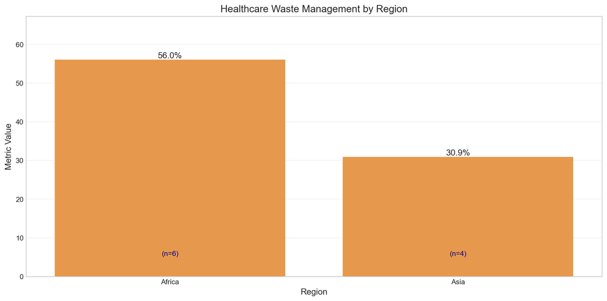

Regional Distribution of Healthcare Waste Management

```python
# Regional analysis of healthcare waste management
# Similar to what we did for paternity leave, but adapted for this indicator
healthcare_region_stats = []

for region, countries in regions.items():
    # Get countries in this region
    region_data = latest_ind2[latest_ind2['country'].isin(countries)]

    if len(region_data) > 0:
        # If the data is categorical (yes/no), count yes responses
        if isinstance(region_data['obs_value'].iloc[0], str):
            yes_count = sum(region_data['obs_value'] == 'Yes')
            total = len(region_data)
            percentage = (yes_count / total) * 100 if total > 0 else 0
        else:
            # If it's numeric, calculate the average
            region_data['obs_value_num'] = pd.to_numeric(region_data['obs_value'], errors='coerce')
            percentage = region_data['obs_value_num'].mean()
            total = len(region_data)

        healthcare_region_stats.append({
            'Region': region,
            'Countries_With_Data': total,
            'Metric': percentage
        })

# Convert to DataFrame
healthcare_region_df = pd.DataFrame(healthcare_region_stats)

if len(healthcare_region_df) > 0:
    # Create the bar chart for healthcare
    plt.figure(figsize=(12, 6))
    ax = sns.barplot(x='Region', y='Metric', data=healthcare_region_df, color=secondary_color)

    # Add percentage labels on bars
    for i, p in enumerate(ax.patches):
        ax.annotate(f"{p.get_height():.1f}%",
                    (p.get_x() + p.get_width() / 2., p.get_height()),
                    ha = 'center', va = 'bottom',
                    fontsize=12)

    # Add text showing countries with data
    for i, row in healthcare_region_df.iterrows():
        ax.annotate(f"(n={row['Countries_With_Data']})",
                    (i, 5), ha='center', va='bottom', color='darkblue',
                    fontsize=10)

    plt.title('Healthcare Waste Management by Region', fontsize=14)
    plt.xlabel('Region', fontsize=12)
    plt.ylabel('Metric Value', fontsize=12)
    plt.ylim(0, max(healthcare_region_df['Metric']) * 1.2)  # Add space for annotations
    plt.grid(axis='y', alpha=0.3)
    plt.tight_layout()
    plt.show()
else:
    print("Insufficient regional data for healthcare waste management")
```

# Comparison Between Indicators

## Regional Comparison of Both Indicators

Comparing these two indicators helps us understand the relationship between family policies and healthcare infrastructure.

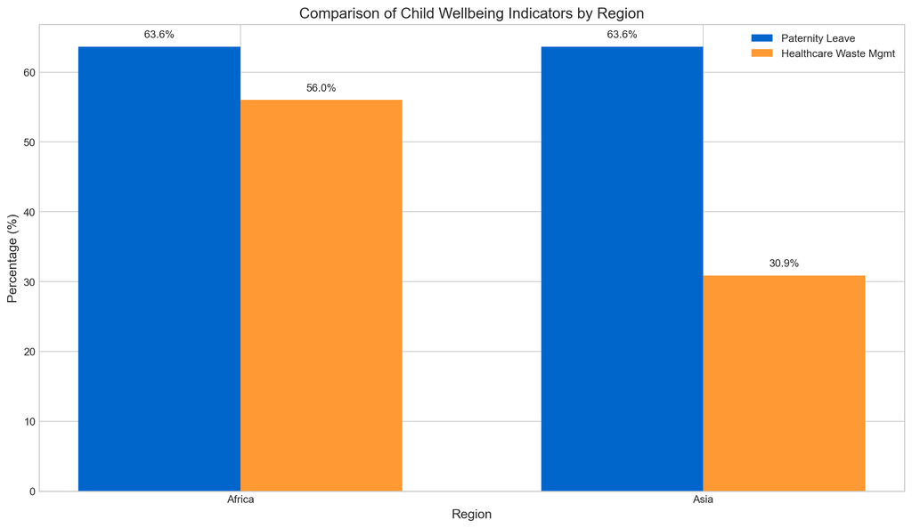

Comparison of Both Indicators by Region

```python
# Combine the regional data from both indicators
if len(region_df) > 0 and len(healthcare_region_df) > 0:
    # Merge the two datasets
    comparison_df = region_df.merge(
        healthcare_region_df,
        on='Region',
        suffixes=('_paternity', '_healthcare')
    )

    if len(comparison_df) > 0:
        # Set up the grouped bar chart
        plt.figure(figsize=(12, 7))

        # Set position of bars
        bar_width = 0.35
        index = np.arange(len(comparison_df))

        # Create bars
        bar1 = plt.bar(index, comparison_df['Percentage'], bar_width,
                       label='Paternity Leave', color=primary_color)
        bar2 = plt.bar(index + bar_width, comparison_df['Metric'], bar_width,
                       label='Healthcare Waste Mgmt', color=secondary_color)

        # Add labels and title
        plt.xlabel('Region', fontsize=12)
        plt.ylabel('Percentage (%)', fontsize=12)
        plt.title('Comparison of Child Wellbeing Indicators by Region', fontsize=14)
        plt.xticks(index + bar_width/2, comparison_df['Region'])
        plt.legend()

        # Add value labels to bars
        def add_labels(bars):
            for bar in bars:
                height = bar.get_height()
                plt.text(bar.get_x() + bar.get_width()/2., height + 1,
                         f'{height:.1f}%', ha='center', va='bottom', fontsize=10)

        add_labels(bar1)
        add_labels(bar2)

        plt.tight_layout()
        plt.show()
    else:
        print("No matching regions between indicators")
else:
    print("Insufficient data for comparison")
```

## Correlation with Child Health Outcomes

We can explore how these indicators correlate with key child health metrics from our metadata.

```python
# Check if we have birth rate or child mortality data
child_health_metrics = ['Birth rate, crude (per 1,000 people)']
available_metrics = [col for col in child_health_metrics if col in metadata.columns]

if available_metrics:
    # Use the first available child health metric
    health_metric = available_metrics[0]

    # Get latest data
    latest_meta = metadata[metadata['year'] == latest_meta_year]

    # Prepare data for paternity leave vs child health
    paternity_health = latest_ind1.merge(
        latest_meta[['country', health_metric]],
        on='country',
        how='inner'
    )

    # Remove rows with missing values
    paternity_health = paternity_health.dropna(subset=[health_metric])

    if len(paternity_health) > 5:
        # Create a box plot
        plt.figure(figsize=(10, 6))

        # Create grouped boxplot
        sns.boxplot(x='obs_value', y=health_metric, data=paternity_health,
                   palette={
                       'Yes': primary_color,
                       'No': '#bbbbbb',
                       '0': secondary_color,
                       '1': highlight_color
                   })

        plt.title(f'Relationship Between Paternity Leave and {health_metric}', fontsize=14)
        plt.xlabel('Paternity Leave Available', fontsize=12)
        plt.ylabel(health_metric, fontsize=12)
        plt.grid(axis='y', alpha=0.3)
        plt.tight_layout()
        plt.show()

        # Calculate and display statistics
        group_means = paternity_health.groupby('obs_value')[health_metric].mean()
        print(f"Average {health_metric} by group:")
        for group, mean in group_means.items():
            print(f"  {group}: {mean:.2f}")
    else:
        print("Insufficient data for child health correlation")
else:
    print("No child health metrics available in metadata")
```

```
Insufficient data for child health correlation
```

# Trends Over Time

## Changes in Paternity Leave Implementation

Let’s examine how paternity leave policies have changed over time.

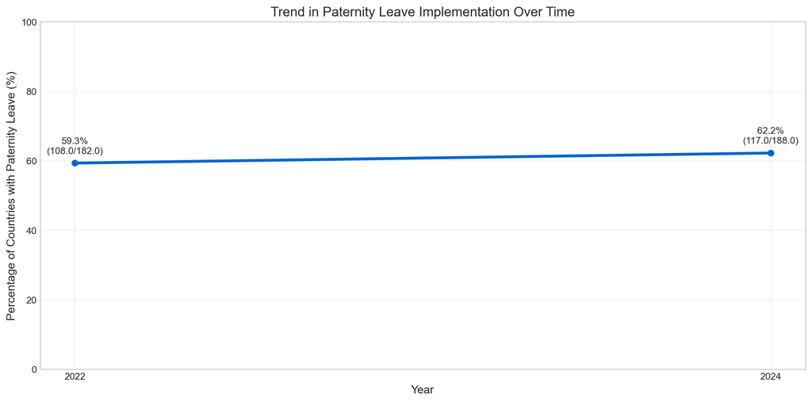

Trends in Paternity Leave Implementation

```python
# Check if we have multiple years of data
years1 = sorted(indicator1['time_period'].unique())

if len(years1) > 1:
    # Create time series data for paternity leave
    paternity_time_series = []

    for year in years1:
        # Get data for this year
        year_data = indicator1[(indicator1['time_period'] == year) &
                             (indicator1['sex'] == 'Total')]

        # Count countries with paternity leave
        yes_count = sum(year_data['obs_value'] == 'Yes')
        total_count = len(year_data)
        percentage = (yes_count / total_count) * 100 if total_count > 0 else 0

        paternity_time_series.append({
            'Year': year,
            'Countries_With_Data': total_count,
            'Countries_With_PaternityLeave': yes_count,
            'Percentage': percentage
        })

    # Convert to DataFrame
    time_df = pd.DataFrame(paternity_time_series)

    # Create line chart
    plt.figure(figsize=(12, 6))

    # Plot percentage line
    plt.plot(time_df['Year'], time_df['Percentage'],
             marker='o', linestyle='-', linewidth=3,
             color=primary_color)

    # Add data labels
    for i, row in time_df.iterrows():
        plt.annotate(f"{row['Percentage']:.1f}%\n({row['Countries_With_PaternityLeave']}/{row['Countries_With_Data']})",
                    (row['Year'], row['Percentage']),
                    textcoords="offset points",
                    xytext=(0,10),
                    ha='center')

    plt.title('Trend in Paternity Leave Implementation Over Time', fontsize=14)
    plt.xlabel('Year', fontsize=12)
    plt.ylabel('Percentage of Countries with Paternity Leave (%)', fontsize=12)
    plt.xticks(time_df['Year'])
    plt.ylim(0, 100)
    plt.grid(True, alpha=0.3)
    plt.tight_layout()
    plt.show()
else:
    print("Not enough years of data for time series analysis")
```

## Healthcare Waste Management Over Time

Similarly, we can track progress in healthcare waste management over time.

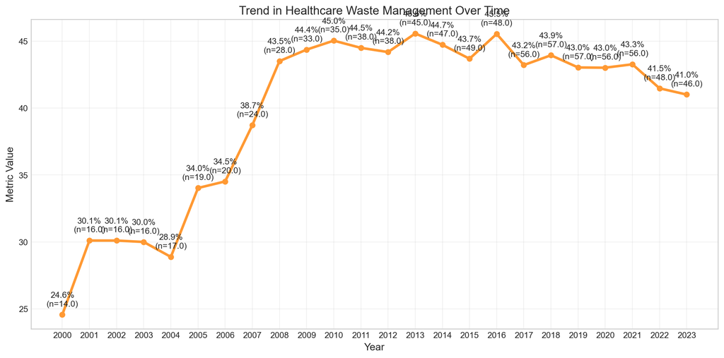

Trends in Healthcare Waste Management

```python
# Check if we have multiple years of data for healthcare
years2 = sorted(indicator2['time_period'].unique())

if len(years2) > 1:
    # Create time series data for healthcare waste management
    healthcare_time_series = []

    for year in years2:
        # Get data for this year
        year_data = indicator2[(indicator2['time_period'] == year) &
                             (indicator2['sex'] == 'Total')]

        # Calculate metric based on data type
        if isinstance(year_data['obs_value'].iloc[0], str) if len(year_data) > 0 else False:
            # For categorical data (Yes/No)
            yes_count = sum(year_data['obs_value'] == 'Yes')
            total_count = len(year_data)
            metric = (yes_count / total_count) * 100 if total_count > 0 else 0
        else:
            # For numeric data, calculate average
            year_data['obs_value_num'] = pd.to_numeric(year_data['obs_value'], errors='coerce')
            metric = year_data['obs_value_num'].mean()
            total_count = len(year_data)

        healthcare_time_series.append({
            'Year': year,
            'Countries_With_Data': total_count,
            'Metric': metric
        })

    # Convert to DataFrame
    healthcare_time_df = pd.DataFrame(healthcare_time_series)

    # Create line chart
    plt.figure(figsize=(12, 6))

    # Plot percentage line
    plt.plot(healthcare_time_df['Year'], healthcare_time_df['Metric'],
             marker='o', linestyle='-', linewidth=3,
             color=secondary_color)

    # Add data labels
    for i, row in healthcare_time_df.iterrows():
        plt.annotate(f"{row['Metric']:.1f}%\n(n={row['Countries_With_Data']})",
                    (row['Year'], row['Metric']),
                    textcoords="offset points",
                    xytext=(0,10),
                    ha='center')

    plt.title('Trend in Healthcare Waste Management Over Time', fontsize=14)
    plt.xlabel('Year', fontsize=12)
    plt.ylabel('Metric Value', fontsize=12)
    plt.xticks(healthcare_time_df['Year'])
    plt.grid(True, alpha=0.3)
    plt.tight_layout()
    plt.show()
else:
    print("Not enough years of data for healthcare time series analysis")
```

# Key Findings and Recommendations

## Recommendations for Policy and Practice

Based on these findings, we recommend:

1. **Expand paternity leave policies** especially in regions with low implementation rates
2. **Invest in healthcare infrastructure** to improve waste management in medical facilities
3. **Study best practices** from high-performing countries to develop appropriate models
4. **Collect more comprehensive data** to better track progress and identify needs
5. **Target interventions** to countries with both low policy implementation and poor health outcomes

## Limitations and Future Research

This analysis has several limitations:

- Data availability varies by country and year
- Binary indicators (Yes/No) don’t capture policy details like leave duration or compensation
- Limited ability to establish causal relationships
- Some regions have few countries with available data

Future research should:

- Incorporate more detailed policy information
- Analyze the connection between these indicators and long-term child development outcomes
- Conduct case studies of successful policy implementations
- Explore the combined impact of multiple child wellbeing policies and services

# References

- UNICEF Child Wellbeing Indicators Dataset
- World Bank Development Indicators
- National family policy documentation
- WHO Healthcare Facility Assessment Guidelines